# IntimacyRatings

# Prepare data

## Note: If you want to save any of the plots from this code, you have to comment out the `png()` and `dev.off()` lines before and after the plot code, and you have to make sure `folder` (and `folder2`) are the right ones where you want your graphs saved.

```r
library(tidyverse)
library(lme4)
library(viridis)
folder <- "C:/Users/offredet/Documents/1HU/ExperimentEyes/IntimacyRatings/"
dat <- read.csv(paste0(folder, "CleanData.csv"))

dat <- dat[dat$Stockholm=="Yes",] # keep only people who live in Stockholm
dat$Stockholm <- NULL # we don't need this column anymore

dat$Participant <- as.factor(dat$Participant)
dat$Gender <- as.factor(dat$Gender)
str(dat)
```

```
## 'data.frame':    148 obs. of  33 variables:
##  $ Participant                                                                                                                     : Factor w/ 148 levels "1","2","3","4",..: 1 2 3 4 5 6 7 8 9 10 ...
##  $ GrewUp                                                                                                                          : chr  "india" "Estonia" "Sweden" "India" ...
##  $ L1                                                                                                                              : chr  "Odia" "Estonian" "Swedish" "Bengali" ...
##  $ Age                                                                                                                             : chr  "32" "38" "34" "40" ...
##  $ Gender                                                                                                                          : Factor w/ 4 levels "Female","Male",..: 2 2 2 1 2 1 2 2 1 1 ...
##  $ For.what.in.your.life.do.you.feel.most.grateful.                                                                                : int  7 3 1 7 4 1 5 6 6 2 ...
##  $ Where.is.somewhere.you.ve.visited.that.you.felt.really.had.an.impact.on.who.you.are.today.                                      : int  7 4 2 7 4 1 4 5 4 1 ...
##  $ How.often.and.where.do.you.get.your.hair.cut.                                                                                   : int  5 1 1 3 1 1 6 3 1 1 ...
##  $ How.many.hours.do.you.work.every.week.                                                                                          : int  3 3 1 3 1 1 3 4 1 1 ...
##  $ Tell.me.about.a.conversation.you.had.with.another.person.earlier.today.                                                         : int  6 3 1 6 2 4 6 6 4 2 ...
##  $ Do.you.like.to.get.up.early.or.stay.up.late..Why.                                                                               : int  2 2 1 1 1 1 4 4 1 1 ...
##  $ How.did.you.get.your.current.job.                                                                                               : int  3 3 1 9 1 1 4 3 2 2 ...
##  $ When.was.the.last.time.you.walked.for.more.than.an.hour..Where.did.you.go..What.did.you.see.                                    : int  2 2 1 2 1 1 5 5 1 1 ...
##  $ What.travel.route.do.you.typically.use.to.get.to.work.school.                                                                   : int  2 1 1 1 1 1 3 4 1 3 ...
```

[output cut: 19 more lines]

```r
dat <- dat[dat$GrewUp!="no of your business",]
dat$GrewUp[dat$GrewUp=="india"] <- "India"
usa <- c("United States ", "US Virgin Islands ")
dat$GrewUp[dat$GrewUp%in%usa] <- "USA"
sweden <- c("sweden", "SE")
dat$GrewUp[dat$GrewUp%in%sweden] <- "Sweden"
dat$GrewUp[dat$GrewUp=="Mornaguia"] <- "Tunisia"
uk <- c("United Kingdom ", "Uk")
dat$GrewUp[dat$GrewUp%in%uk] <- "UK"
dat$GrewUp[dat$GrewUp=="The Netherlands"] <- "Netherlands"
dat$GrewUp <- trimws(dat$GrewUp, which="right")

table(dat$GrewUp)
```

```
##
##            Australia              Austria              Belgium
##                    1                    1                    2
##               Brazil               Canada              Croatia
##                    4                    1                    1
##               Cyprus              Estonia               France
##                    1                    1                    3
##              Germany               Greece                India
##                   10                    1                    8
##              Ireland                Italy               Latvia
##                    1                    1                    1
##              Lebanon              Liberia            Macedonia
##                    1                    1                    1
##          Netherlands              Romania         Saudi Arabia
##                    6                    2                    1
##               Serbia             Slovakia         South Africa
##                    1                    1                    3
##                Spain               Sweden          Switzerland
##                    3                   73                    4
##              Tunisia               Turkey                   UK
##                    1                    1                    4
## United Arab Emirates                  USA            Venezuela
##                    1                    5                    1
```

There seem to be around half Swedish and half foreign respondents.

```r
dat$Swedish[dat$GrewUp=="Sweden"] <- "Swedish"
dat$Swedish[dat$GrewUp!="Sweden"] <- "NotSwedish"

dat$Swedish <- as.factor(dat$Swedish)

table(dat$Swedish)
```

```
##
## NotSwedish    Swedish
##         74         73
```

Below I group the countries into world region, but *warning*: I followed my intuition for some of them, not an objective definition.

```r
asia <- c("India")
southamerica <- c("Brazil", "Venezuela")
northamerica <- c("USA", "Canada")
westeurope <- c("Netherlands", "Belgium", "France", "Switzerland", "Germany", "Austria", "Ireland", "UK")
easteurope <- c("Estonia", "Slovakia", "Romania", "Latvia")
southeurope <- c("Greece", "Croatia", "Serbia", "Italy", "Spain", "Macedonia")
africa <- c("South Africa", "Liberia", "Tunisia")
oceania <- c("Australia")
middleeast <- c("United Arab Emirates", "Cyprus", "Turkey", "Lebanon", "Saudi Arabia")

dat$WorldRegion[dat$GrewUp %in% asia] <- "Asia"
dat$WorldRegion[dat$GrewUp %in% southamerica] <- "South America"
dat$WorldRegion[dat$GrewUp %in% northamerica] <- "North America"
dat$WorldRegion[dat$GrewUp %in% westeurope] <- "Western Europe"
dat$WorldRegion[dat$GrewUp %in% easteurope] <- "Eastern Europe"
dat$WorldRegion[dat$GrewUp %in% southeurope] <- "Southern Europe"
dat$WorldRegion[dat$GrewUp ==  "Sweden"] <- "Sweden"
dat$WorldRegion[dat$GrewUp %in% africa] <- "Africa"
dat$WorldRegion[dat$GrewUp %in% oceania] <- "Oceania"
dat$WorldRegion[dat$GrewUp %in% middleeast] <- "Middle East"

dat$WorldRegion <- as.factor(dat$WorldRegion)

table(dat$WorldRegion)
```

```
##
##          Africa            Asia  Eastern Europe     Middle East   North America
##               5               8               5               5               6
##         Oceania   South America Southern Europe          Sweden  Western Europe
##               1               5               8              73              31
```

```r
dat$L1 <- trimws(dat$L1, which="right")
dat$L1[dat$L1=="SE"] <- "Swedish"
dat$L1[dat$L1=="English swedish"] <- "English, Swedish"

unique(dat$L1)
```

```
##  [1] "Odia"
##  [2] "Estonian"
##  [3] "Swedish"
##  [4] "Bengali"
##  [5] "Bangla"
##  [6] "English"
##  [7] "Dutch"
##  [8] "English, French"
##  [9] "Greek"
## [10] "French"
## [11] "Portuguese"
## [12] "Kannada"
## [13] "German"
## [14] "Croatian"
## [15] "German, Croatian"
```

[output cut: 30 more lines]

```r
dat$Age[dat$Age=="35 years"] <- 35
dat$Age <- as.numeric(dat$Age)
summary(dat$Age)
```

```
##    Min. 1st Qu.  Median    Mean 3rd Qu.    Max.
##   18.00   24.00   29.00   29.35   33.00   50.00
```

```r
sd(dat$Age)
```

```
## [1] 6.896299
```

```r
table(dat$Gender)
```

```
##
##            Female              Male        Non-binary Prefer not to say
##                68                76                 1                 2
```

```r
questions <- cbind(qnames <- colnames(dat[c(6:33)]),
                   qno <- paste0("Q", c(1:length(qnames)))) # save object with questions and their corresponding number

names(dat)[c(6:33)] <- paste0(qno)
dat[, c(6:33)] <- lapply(dat[, c(6:33)], as.numeric)
head(dat)
```

```
##   Participant  GrewUp       L1 Age Gender Q1 Q2 Q3 Q4 Q5 Q6 Q7 Q8 Q9 Q10 Q11
## 1           1   India     Odia  32   Male  7  7  5  3  6  2  3  2  2   9   8
## 2           2 Estonia Estonian  38   Male  3  4  1  3  3  2  3  2  1   6   4
## 3           3  Sweden  Swedish  34   Male  1  2  1  1  1  1  1  1  1   2   3
## 4           4   India  Bengali  40 Female  7  7  3  3  6  1  9  2  1   9   9
## 5           5   India   Bangla  36   Male  4  4  1  1  2  1  1  1  1   5   3
## 6           6  Sweden  Swedish  47 Female  1  1  1  1  4  1  1  1  1   6   3
##   Q12 Q13 Q14 Q15 Q16 Q17 Q18 Q19 Q20 Q21 Q22 Q23 Q24 Q25 Q26 Q27 Q28
## 1   1   5   2   8   3   2   2   8   2   1   2   2   8   1   2   9   1
## 2   2   2   2   6   4   1   1   5   1   1   3   2   5   5   3   7   2
## 3   1   1   1   2   1   1   1   1   1   1   1   1   3   2   1   5   1
## 4   1   7   6   9   6   1   6   6   1   1   1   1   9   9   6   9   1
## 5   4   2   1   4   1   2   1   3   2   1   1   1   1   1   3   5   1
## 6   1   3   1   6   3   1   1   4   1   3   1   1   1   1   4   3   1
##      Swedish    WorldRegion
## 1 NotSwedish           Asia
## 2 NotSwedish Eastern Europe
## 3    Swedish         Sweden
## 4 NotSwedish           Asia
## 5 NotSwedish           Asia
## 6    Swedish         Sweden
```

# Analyze it

## Per participant

```r
dl <- gather(dat, Question, Rating, Q1:Q28) # turn data into long format
```

### Gender

See below: Gender doesn’t seem to influence the ratings.

```r
summary(lmer(Rating ~ Gender + (1|Participant), data=dl))
```

```
## Linear mixed model fit by REML ['lmerMod']
## Formula: Rating ~ Gender + (1 | Participant)
##    Data: dl
##
## REML criterion at convergence: 18227.4
##
## Scaled residuals:
##     Min      1Q  Median      3Q     Max
## -2.1739 -0.7190 -0.2442  0.6471  3.1046
##
## Random effects:
##  Groups      Name        Variance Std.Dev.
##  Participant (Intercept) 1.497    1.224
##  Residual                4.519    2.126
## Number of obs: 4116, groups:  Participant, 147
##
## Fixed effects:
##                         Estimate Std. Error t value
## (Intercept)              3.46218    0.15619  22.167
## GenderMale              -0.09423    0.21499  -0.438
## GenderNon-binary         0.43067    1.29738   0.332
## GenderPrefer not to say  0.96639    0.92401   1.046
##
## Correlation of Fixed Effects:
##             (Intr) GndrMl GndrN-
## GenderMale  -0.726
## GndrNn-bnry -0.120  0.087
## GndrPrfrnts -0.169  0.123  0.020
```

### Age

Age also doesn’t seem to influence the ratings.

```r
summary(lmer(Rating ~ Age + (1|Participant), data=dl))
```

```
## Linear mixed model fit by REML ['lmerMod']
## Formula: Rating ~ Age + (1 | Participant)
##    Data: dl
##
## REML criterion at convergence: 18238.1
##
## Scaled residuals:
##     Min      1Q  Median      3Q     Max
## -2.1266 -0.7184 -0.2464  0.6486  3.1040
##
## Random effects:
##  Groups      Name        Variance Std.Dev.
##  Participant (Intercept) 1.491    1.221
##  Residual                4.519    2.126
## Number of obs: 4116, groups:  Participant, 147
##
## Fixed effects:
##              Estimate Std. Error t value
## (Intercept)  3.593571   0.465036   7.728
## Age         -0.005588   0.015425  -0.362
##
## Correlation of Fixed Effects:
##     (Intr)
## Age -0.974
```

### Where they grew up

The place where they come from doesn’t seem to change their ratings too much, only people from Africa.

Swedish people tended to rate the questions as slightly less intimate than foreigners.

```r
dl$WorldRegion <- relevel(dl$WorldRegion, ref=9) # making Sweden the reference level
summary(lmer(Rating ~ WorldRegion + (1|Participant), data=dl))
```

```
## Linear mixed model fit by REML ['lmerMod']
## Formula: Rating ~ WorldRegion + (1 | Participant)
##    Data: dl
##
## REML criterion at convergence: 18207.6
##
## Scaled residuals:
##     Min      1Q  Median      3Q     Max
## -2.1386 -0.7254 -0.2421  0.6386  3.0984
##
## Random effects:
##  Groups      Name        Variance Std.Dev.
##  Participant (Intercept) 1.374    1.172
##  Residual                4.519    2.126
## Number of obs: 4116, groups:  Participant, 147
##
## Fixed effects:
##                            Estimate Std. Error t value
## (Intercept)                 3.15900    0.14500  21.785
## WorldRegionAfrica           2.19100    0.57272   3.826
## WorldRegionAsia             0.65350    0.46140   1.416
## WorldRegionEastern Europe   0.05528    0.57272   0.097
## WorldRegionMiddle East      0.41243    0.57272   0.720
## WorldRegionNorth America    0.03147    0.52616   0.060
## WorldRegionOceania          1.37671    1.24738   1.104
## WorldRegionSouth America    0.78386    0.57272   1.369
## WorldRegionSouthern Europe  0.65350    0.46140   1.416
## WorldRegionWestern Europe   0.33985    0.26559   1.280
##
## Correlation of Fixed Effects:
##             (Intr) WrldRgnAf WrldRgnAs WrlREE WrlRME WrlRNA WrldRO WrlRSA
## WrldRgnAfrc -0.253
## WorldRegnAs -0.314  0.080
## WrldRgnEstE -0.253  0.064     0.080
## WrldRgnMddE -0.253  0.064     0.080     0.064
## WrldRgnNrtA -0.276  0.070     0.087     0.070  0.070
## WorldRgnOcn -0.116  0.029     0.037     0.029  0.029  0.032
## WrldRgnSthA -0.253  0.064     0.080     0.064  0.064  0.070  0.029
## WrldRgnSthE -0.314  0.080     0.099     0.080  0.080  0.087  0.037  0.080
## WrldRgnWstE -0.546  0.138     0.172     0.138  0.138  0.150  0.063  0.138
##             WrlRSE
## WrldRgnAfrc
## WorldRegnAs
## WrldRgnEstE
## WrldRgnMddE
## WrldRgnNrtA
## WorldRgnOcn
## WrldRgnSthA
## WrldRgnSthE
## WrldRgnWstE  0.172
```

```r
summary(lmer(Rating ~ Swedish + (1|Participant), data=dl))
```

```
## Linear mixed model fit by REML ['lmerMod']
## Formula: Rating ~ Swedish + (1 | Participant)
##    Data: dl
##
## REML criterion at convergence: 18226.4
##
## Scaled residuals:
##     Min      1Q  Median      3Q     Max
## -2.1358 -0.7305 -0.2395  0.6428  3.0906
##
## Random effects:
##  Groups      Name        Variance Std.Dev.
##  Participant (Intercept) 1.419    1.191
##  Residual                4.519    2.126
## Number of obs: 4116, groups:  Participant, 147
##
## Fixed effects:
##                Estimate Std. Error t value
## (Intercept)      3.6964     0.1461  25.293
## SwedishSwedish  -0.5374     0.2074  -2.591
##
## Correlation of Fixed Effects:
##             (Intr)
## SwedshSwdsh -0.705
```

### Individual ratings

See the graph: some people rated the questions (almost) all the same. We should exclude those. (The colors in the graph don’t mean anything, they’re just pretty.)

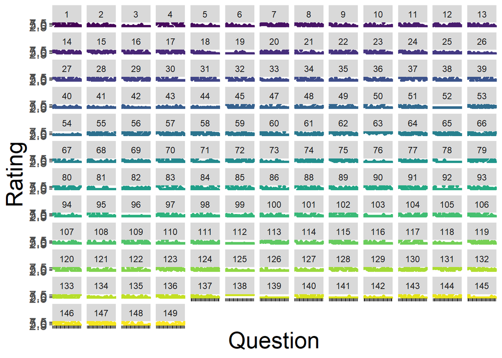

```r
# png(paste0(folder, "IndividualRatings.png"), width=1000, height=1000)
ggplot(data=dl, aes(x=Question, y=Rating, color=Participant))+
  geom_point()+
  facet_wrap(~Participant)+
  theme(legend.position = "none", axis.title=element_text(size=23), axis.text.y=element_text(size=13), axis.text.x=element_blank())+
  scale_color_viridis_d()
```

```r
# dev.off()
```

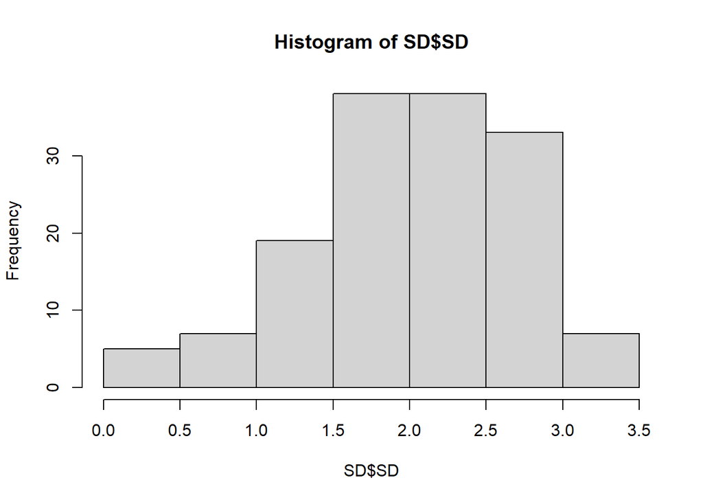

```r
# Calculate standard deviation of each person's ratings

SD <- aggregate(dl$Rating, by=list(dl$Participant), FUN=sd)
colnames(SD) <- c("Participant", "SD")
dl1 <- merge(dl, SD, by="Participant")

hist(SD$SD)
```

```r
threshold <- mean(SD$SD) - (sd(SD$SD)*2)
```

Deleting participants by number of questions rated the same

```r
bad <- vector()

for(i in unique(dl$Participant)){
  if(any(data.frame(table(dl$Rating[dl$Participant==i]))$Freq >= 20)){ # 20 is 70% of 28 questions
    bad[i] <- i
  }
}

bad
```

```
##     3    19    52    54    76    78    81    92    96   103   112   125   138
##   "3"  "19"  "52"  "54"  "76"  "78"  "81"  "92"  "96" "103" "112" "125" "138"
##   139   141   142   145
## "139" "141" "142" "145"
```

```r
`%!in%` <- Negate(`%in%`)
dlr <- dl[dl$Participant %!in% bad,]
dlbad <- dl[dl$Participant %in% bad,]
```

Now plot it again to see who’s left…

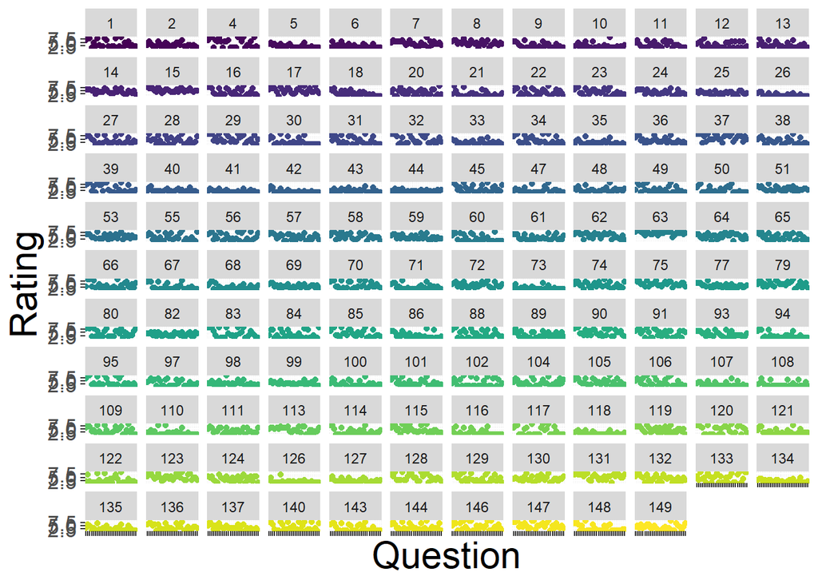

```r
# png(paste0(folder, "IndividualRatingsReduced.png"), width=1000, height=1000)
ggplot(data=dlr, aes(x=Question, y=Rating, color=Participant))+
  geom_point()+
  facet_wrap(~Participant)+
  theme(legend.position = "none", axis.title=element_text(size=23), axis.text.y=element_text(size=13), axis.text.x=element_blank())+
  scale_color_viridis_d()
```

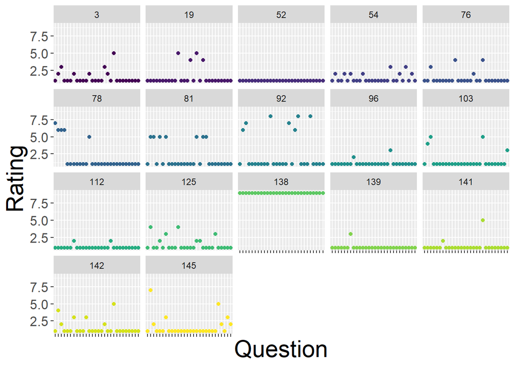

```r
# dev.off()
#
# png(paste0(folder, "IndividualRatingsBad.png"), width=1000, height=1000)
ggplot(data=dlbad, aes(x=Question, y=Rating, color=Participant))+
  geom_point()+
  facet_wrap(~Participant)+
  theme(legend.position = "none", axis.title=element_text(size=23), axis.text.y=element_text(size=13), axis.text.x=element_blank())+
  scale_color_viridis_d()
```

```r
# dev.off()
```

And rename the participants so it’s less confusing:

```r
dt <- dat[dat$Participant %!in% bad,] # we need to use the wide data format

dt$Participant <- 1:nrow(dt)

length(unique(dt$Participant)) # 130 participants
```

```
## [1] 130
```

```r
# but now turn it into long again

dl <- gather(dt, Question, Rating, Q1:Q28)
```

We used the ratings of 130 participants.

## Per question

```r
qratmean <- aggregate(dl$Rating, by=list(dl$Question), FUN=mean)
colnames(qratmean) <- c("Q", "mean")
qratmed <- aggregate(dl$Rating, by=list(dl$Question), FUN=median)
colnames(qratmed) <- c("Q", "median")
qratsd <- aggregate(dl$Rating, by=list(dl$Question), FUN=sd)
colnames(qratsd) <- c("Q", "SD")
qratg <- merge(qratmean, qratmed, by="Q")
qrat <- merge(qratg, qratsd, by="Q")
qrat$Q <- as.factor(qrat$Q)
```

Plotting the questions

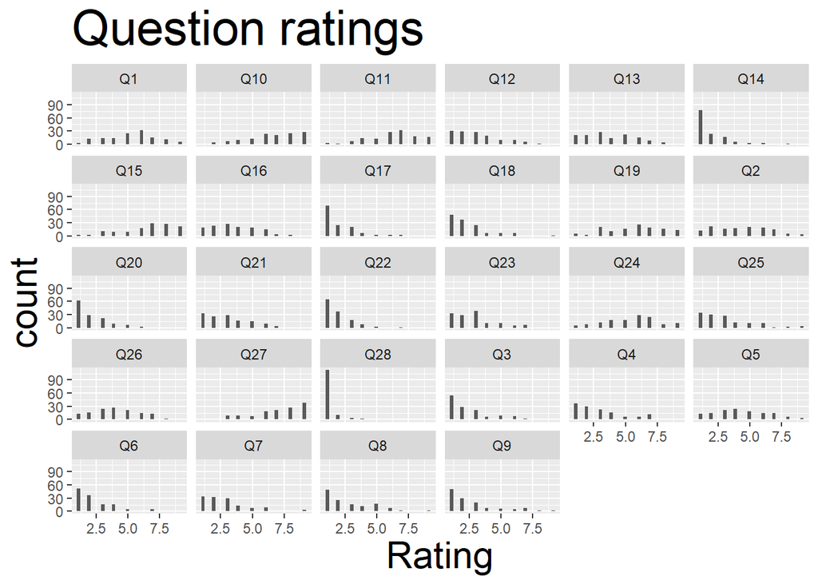

```r
# folder2 <- "C:/Users/tomof/Documents/1.Humboldt-Universität_zu_Berlin/ExperimentEyes/IntimacyRatings/Questions/"
#
# png(paste0(folder2, "QHist.png"), width=1000, height=1000)
ggplot(dl, aes(Rating))+
  geom_histogram()+
  facet_wrap(~Question)+
  ggtitle("Question ratings")+
  theme(axis.title=element_text(size=23), title=element_text(size=25))
```

```r
# dev.off()
#
# plots <- list()
#
# plots[[1]] <- ggplot(dl, aes(Rating))+
#   geom_histogram()+
#   ggtitle("Ratings of all questions")
#
# plots[[2]] <- ggplot(qrat, aes(mean))+
#   geom_histogram()+
#   ggtitle("Mean ratings")
#
# plots[[3]] <- ggplot(qrat, aes(median))+
#   geom_histogram()+
#   ggtitle("Medians of ratings")
#
# plots[[4]] <- ggplot(qrat, aes(SD))+
#   geom_histogram()+
#   ggtitle("SD of ratings of each question (lots of variability)")
#
# png(paste0(folder2, "Histograms.png"), width=1000, height=1000)
# plot_grid(plotlist=plots)
# dev.off()
```

```r
colnames(questions) <- c("question", "Q")
q <- merge(questions, qrat, by="Q")

qByMean <- q[order(q$mean),] # the median is also already sorted, except for one case. so we can just leave it like that.

write.csv(qByMean, file=paste0(folder, "OrderedQuestions.csv"))
```